# EDA

## 6. Sprawdźmy jak wygląda czas od ostatniego zamówienia w zależności od członkostwa

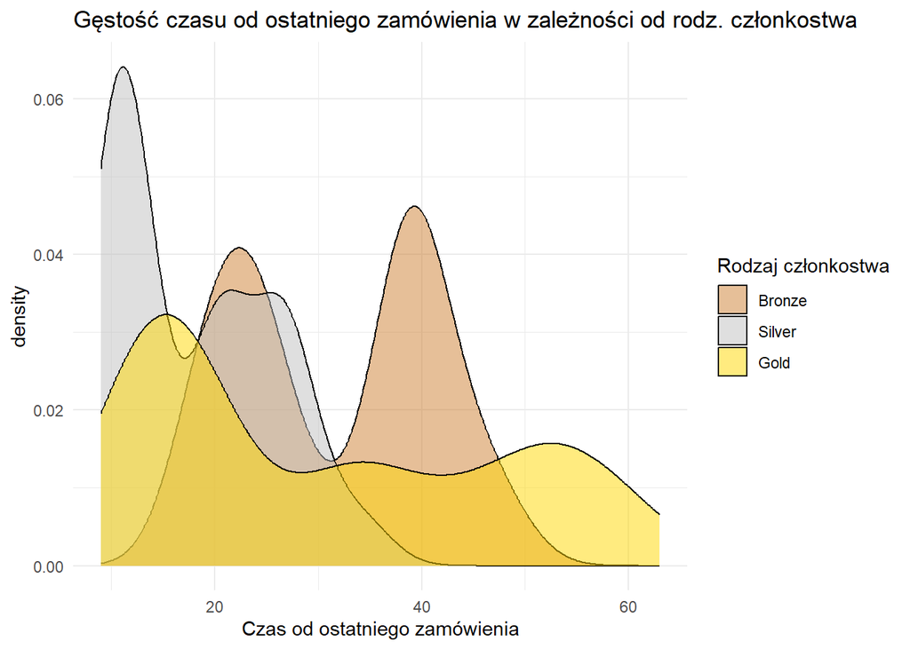

```r
custom_colors <- c("Gold" = "#FFD700", "Silver" = "#C0C0C0", "Bronze" = "#CD7F32")

ecommerce %>%
  ggplot() +
  geom_density(aes(x = Days.Since.Last.Purchase, fill = Membership.Type), alpha = 0.5) +
  labs(title = "Gęstość czasu od ostatniego zamówienia w zależności od rodz. członkostwa", x = "Czas od ostatniego zamówienia", fill = "Rodzaj członkostwa") +
  scale_fill_manual(values = custom_colors) +
  theme_minimal()
```

Najszybciej kolejnego zamówienia dokonują osoby, które posiadają członkostwo `Silver`. Praktycznie nikt z tej grupy nie dokonuje później zamówienia niż 40 dni. Co może być wynikiem tego, że ta grupa należała do usatysfakcjonowanych klientów z usług, więc szybciej dokonywała kolejnych zamówień. Również część klientów posiadająca status `Gold` dokonuje dość szybko kolejnego zamówienia, poniżej 20 dni, jest to zapewne ta niewielka część osób, która była usatysfacjonowana z usług. Jednak później czas od ostatniego zamówienia jest dość równomiernie rozłożony. W tej grupie też jest największy odsetek osób, których czas od ostatniego zamówienia przekroczył 50 dni. Widać, że rozkład czasu od ostatniego zamówienia wśród członków `Bronze` ma rozkład dwumodalny. Mamy tutaj rozbieżność, bo klienci z tej grupy najczęściej zamawiali między 20-25 dniami albo 35-45 dniami.

## 7.Zobaczmy zatem jakie są średnie oceny produktów w zależności od poziomu zadowolenia z usługi:

```r
ecommerce %>%
  group_by(Satisfaction.Level) %>%
  summarise(liczba = n(),
            średnia = mean(Average.Rating),
            mediana = median(Average.Rating),
            odchyl_stand = sd(Average.Rating)) %>%
  arrange(średnia)
```

| Satisfaction.Level | liczba | średnia | mediana | odchyl_stand |
| --- | --- | --- | --- | --- |
| Neutral | 107 | 3.655140 | 3.40 | 0.5077203 |
| Unsatisfied | 116 | 3.692241 | 3.65 | 0.2722374 |
| Satisfied | 125 | 4.646400 | 4.70 | 0.1965608 |

Najwyższe średnie oceny mają osoby, które były usatysfakcjonowane z usługi, ich oceny są skoncentrowane wokół średniej, o czym świadczy niewielkie odchylenie standardowe. Wskazuje to na ogólne zadowolenie z usługi i zamówionych produktów. Natomiast oceny osób z grupy `Neutral` i `Unsatisfied` są do siebie zbliżone. Aczkolwiek rozkład osób z grupy `Neutral` jest bardziej rozproszony, czyli większy wpływ na ocenę miał tutaj otrzymany produkt niż samo zadowolenie z usług.